## Image Cleaner Widget

fastai offers several widgets to support the workflow of a deep learning practitioner. The purpose of the widgets are to help you organize, clean, and prepare your data for your model. Widgets are separated by data type.

```python
path = untar_data(URLs.MNIST_SAMPLE)
data = ImageDataBunch.from_folder(path)
```

```python
learn = cnn_learner(data, models.resnet18, metrics=error_rate)
```

```python
learn.fit_one_cycle(2)
```

| epoch | train_loss | valid_loss | error_rate | time |
| --- | --- | --- | --- | --- |
| 0 | 0.233059 | 0.115309 | 0.033857 | 00:10 |
| 1 | 0.110543 | 0.085249 | 0.028459 | 00:10 |

```python
learn.save('stage-1')
```

We create a databunch with all the data in the training set and no validation set (DatasetFormatter uses only the training set)

```python
db = (ImageList.from_folder(path)
                   .split_none()
                   .label_from_folder()
                   .databunch())
```

```python
learn = cnn_learner(db, models.resnet18, metrics=[accuracy])
learn.load('stage-1');
```

`class` `DatasetFormatter`[[source]](https://github.com/fastai/fastai/blob/master/fastai/widgets/image_cleaner.py#L18)[test]

> `DatasetFormatter`()

×

Tests found for `DatasetFormatter`:

Some other tests where `DatasetFormatter` is used:

- `pytest -sv tests/test_widgets_image_cleaner.py::test_image_cleaner_with_data_from_csv` [[source]](https://github.com/fastai/fastai/blob/master/tests/test_widgets_image_cleaner.py#L37)

To run tests please refer to this guide.

Returns a dataset with the appropriate format and file indices to be displayed.

The `DatasetFormatter` class prepares your image dataset for widgets by returning a formatted `DatasetTfm` based on the `DatasetType` specified. Use `from_toplosses` to grab the most problematic images directly from your learner. Optionally, you can restrict the formatted dataset returned to `n_imgs`.

`from_similars`[[source]](https://github.com/fastai/fastai/blob/master/fastai/widgets/image_cleaner.py#L40)[test]

> `from_similars`(**`learn`**, **`layer_ls`**:`list`=*`[0, 7, 2]`*, **`kwargs`)

×

Tests found for `from_similars`:

Some other tests where `from_similars` is used:

- `pytest -sv tests/test_widgets_image_cleaner.py::test_image_cleaner_with_data_from_csv` [[source]](https://github.com/fastai/fastai/blob/master/tests/test_widgets_image_cleaner.py#L37)

To run tests please refer to this guide.

Gets the indices for the most similar images.

`from_toplosses`[[source]](https://github.com/fastai/fastai/blob/master/fastai/widgets/image_cleaner.py#L20)[test]

> `from_toplosses`(**`learn`**, **`n_imgs`**=*`None`*, **`kwargs`)

×

No tests found for `from_toplosses`. To contribute a test please refer to this guide and [this discussion](https://forums.fast.ai/t/improving-expanding-functional-tests/32929).

Gets indices with top losses.

`from_most_unsure`[[source]](https://github.com/fastai/fastai/blob/master/fastai/widgets/image_cleaner.py#L102)[test]

> `from_most_unsure`(**`learn`**:`Learner`, **`num`**=*`50`*) → `Tuple`[[`DataLoader`](https://pytorch.org/docs/stable/data.html#torch.utils.data.DataLoader), `List`[`int`], `Sequence`[`str`], `List`[`str`]]

×

No tests found for `from_most_unsure`. To contribute a test please refer to this guide and [this discussion](https://forums.fast.ai/t/improving-expanding-functional-tests/32929).

Gets `num` items from the test set, for which the difference in probabilities between the most probable and second most probable classes is minimal.

`class` `ImageCleaner`[[source]](https://github.com/fastai/fastai/blob/master/fastai/widgets/image_cleaner.py#L218)[test]

> `ImageCleaner`(**`dataset`**:`LabelLists`, **`fns_idxs`**:`Collection`[`int`], **`path`**:`PathOrStr`, **`batch_size`**=*`5`*, **`duplicates`**=*`False`*) :: `BasicImageWidget`

×

Tests found for `ImageCleaner`:

- `pytest -sv tests/test_widgets_image_cleaner.py::test_image_cleaner_index_length_mismatch` [[source]](https://github.com/fastai/fastai/blob/master/tests/test_widgets_image_cleaner.py#L16)

- `pytest -sv tests/test_widgets_image_cleaner.py::test_image_cleaner_length_correct` [[source]](https://github.com/fastai/fastai/blob/master/tests/test_widgets_image_cleaner.py#L23)

- `pytest -sv tests/test_widgets_image_cleaner.py::test_image_cleaner_with_data_from_csv` [[source]](https://github.com/fastai/fastai/blob/master/tests/test_widgets_image_cleaner.py#L37)

- `pytest -sv tests/test_widgets_image_cleaner.py::test_image_cleaner_wrong_input_type` [[source]](https://github.com/fastai/fastai/blob/master/tests/test_widgets_image_cleaner.py#L30)

To run tests please refer to this guide.

Displays images for relabeling or deletion and saves changes in `path` as 'cleaned.csv'.

`ImageCleaner` is for cleaning up images that don't belong in your dataset. It renders images in a row and gives you the opportunity to delete the file from your file system. To use `ImageCleaner` we must first use `DatasetFormatter().from_toplosses` to get the suggested indices for misclassified images.

```python
ds, idxs = DatasetFormatter().from_toplosses(learn)
```

```python
ImageCleaner(ds, idxs, path)
```

```
<fastai.widgets.image_cleaner.ImageCleaner at 0x7f45bd324240>
```

`ImageCleaner` does not change anything on disk (neither labels or existence of images). Instead, it creates a 'cleaned.csv' file in your data path from which you need to load your new databunch for the files to changes to be applied.

```python
df = pd.read_csv(path/'cleaned.csv', header='infer')
```

```python
# We create a databunch from our csv. We include the data in the training set and we don't use a validation set (DatasetFormatter uses only the training set)
np.random.seed(42)
db = (ImageList.from_df(df, path)
                   .split_none()
                   .label_from_df()
                   .databunch(bs=64))
```

```python
learn = cnn_learner(db, models.resnet18, metrics=error_rate)
learn = learn.load('stage-1')
```

You can then use `ImageCleaner` again to find duplicates in the dataset. To do this, you can specify `duplicates=True` while calling ImageCleaner after getting the indices and dataset from `.from_similars`. Note that if you are using a layer's output which has dimensions `(n_batches, n_features, 1, 1)` then you don't need any pooling (this is the case with the last layer). The suggested use of `.from_similars()` with resnets is using the last layer and no pooling, like in the following cell.

```python
ds, idxs = DatasetFormatter().from_similars(learn, layer_ls=[0,7,1], pool=None)
```

```
Getting activations...
```

100.00% [226/226 00:02<00:00]

```
Computing similarities...
```

```python
ImageCleaner(ds, idxs, path, duplicates=True)
```

```
<fastai.widgets.image_cleaner.ImageCleaner at 0x7f236f7214a8>
```

`class` `PredictionsCorrector`[[source]](https://github.com/fastai/fastai/blob/master/fastai/widgets/image_cleaner.py#L296)[test]

> `PredictionsCorrector`(**`dataset`**:`LabelLists`, **`fns_idxs`**:`Collection`[`int`], **`classes`**:`Sequence`[`str`], **`labels`**:`Sequence`[`str`], **`batch_size`**:`int`=*`5`*) :: `BasicImageWidget`

×

No tests found for `PredictionsCorrector`. To contribute a test please refer to this guide and [this discussion](https://forums.fast.ai/t/improving-expanding-functional-tests/32929).

Displays images for manual inspection and relabelling.

In competitions, you need to provide predictions for the test set, for which true labels are unknown. You can slightly improve your score by manually correcting the most egregious misclassifications. Test set in competitions is usually large and cannot be inspected manually in its entirety. A good subset to look at is the images the model is the least sure about, i.e. the difference in probabilities between the most probable and the second most probable classes is minimal.

Let's start by creating an artificial test set and training a model:

```python
db_test = ImageDataBunch.from_folder(path/'train', valid_pct = 0.2, test = '../valid')
learn = cnn_learner(db_test, models.resnet18, metrics=[accuracy])
learn.fit_one_cycle(2)
```

| epoch | train_loss | valid_loss | accuracy | time |
| --- | --- | --- | --- | --- |
| 0 | 0.245369 | 0.138495 | 0.953610 | 02:14 |
| 1 | 0.133183 | 0.103801 | 0.963695 | 02:16 |

Now we can take a look at the most unsure images:

```python
most_unsure = DatasetFormatter.from_most_unsure(learn)
wgt = PredictionsCorrector(*most_unsure)
```

```
'No images to show :)'
```

[figure not shown]

`show_corrections`[[source]](https://github.com/fastai/fastai/blob/master/fastai/widgets/image_cleaner.py#L304)[test]

> `show_corrections`(**`ncols`**:`int`, **`fig_kw`)

×

No tests found for `show_corrections`. To contribute a test please refer to this guide and [this discussion](https://forums.fast.ai/t/improving-expanding-functional-tests/32929).

Shows a grid of images whose predictions have been corrected.

When you finished interacting with a widget, you can take a look at the corrections that were made. `show_corrections` displays image's index in the test set, previous label and the new label.

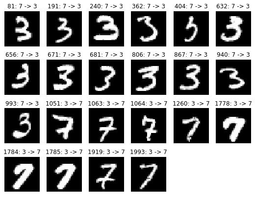

```python
wgt.show_corrections(ncols=6, figsize=(9, 7))
```

`corrected_labels`[[source]](https://github.com/fastai/fastai/blob/master/fastai/widgets/image_cleaner.py#L319)[test]

> `corrected_labels`() → `List`[`str`]

×

No tests found for `corrected_labels`. To contribute a test please refer to this guide and [this discussion](https://forums.fast.ai/t/improving-expanding-functional-tests/32929).

Returns labels for the entire test set with corrections applied.

```python
show_doc(ImageDownloader)
```

`class` `ImageDownloader`[[source]](https://github.com/fastai/fastai/blob/master/fastai/widgets/image_downloader.py#L16)[test]

> `ImageDownloader`(**`path`**:`PathOrStr`=*`'data'`*)

×

Tests found for `ImageDownloader`:

- `pytest -sv tests/test_widgets_image_cleaner.py::test_image_downloader_with_path` [[source]](https://github.com/fastai/fastai/blob/master/tests/test_widgets_image_cleaner.py#L45)

To run tests please refer to this guide.

Displays a widget that allows searching and downloading images from google images search in a Jupyter Notebook or Lab.

`ImageDownloader` widget gives you a way to quickly bootstrap your image dataset without leaving the notebook. It searches and downloads images that match the search criteria and resolution / quality requirements and stores them on your filesystem within the provided `path`.

Images for each search query (or label) are stored in a separate folder within `path`. For example, if you pupulate `tiger` with a `path` setup to `./data`, you'll get a folder `./data/tiger/` with the tiger images in it.

`ImageDownloader` will automatically clean up and verify the downloaded images with `verify_images()` after downloading them.

```python
path = Config.data_path()/'image_downloader'
os.makedirs(path, exist_ok=True)
ImageDownloader(path)
```

```
<fastai.widgets.image_downloader.ImageDownloader at 0x7f236c056358>
```

#### Downloading images in python scripts outside Jupyter notebooks

```python
path = Config.data_path()/'image_downloader'
files = download_google_images(path, 'aussie shepherd', size='>1024*768', n_images=30)

len(files)
```

100.00% [30/30 00:00<00:00]

100.00% [30/30 00:00<00:00]

```
30
```

`download_google_images`[[source]](https://github.com/fastai/fastai/blob/master/fastai/widgets/image_downloader.py#L78)[test]

> `download_google_images`(**`path`**:`PathOrStr`, **`search_term`**:`str`, **`size`**:`str`=*`'>400*300'`*, **`n_images`**:`int`=*`10`*, **`format`**:`str`=*`'jpg'`*, **`max_workers`**:`int`=*`16`*, **`timeout`**:`int`=*`4`*) → `FilePathList`

×

No tests found for `download_google_images`. To contribute a test please refer to this guide and [this discussion](https://forums.fast.ai/t/improving-expanding-functional-tests/32929).

Search for `n_images` images on Google, matching `search_term` and `size` requirements, download them into `path`/`search_term` and verify them, using `max_workers` threads.

After populating images with `ImageDownloader`, you can get a an `ImageDataBunch` by calling `ImageDataBunch.from_folder(path, size=size)`, or using the data block API.

```python
# Setup path and labels to search for
path = Config.data_path()/'image_downloader'
labels = ['boston terrier', 'french bulldog']

# Download images
for label in labels:
    download_google_images(path, label, size='>400*300', n_images=50)

# Build a databunch and train!
src = (ImageList.from_folder(path)
       .split_by_rand_pct()
       .label_from_folder()
       .transform(get_transforms(), size=224))

db  = src.databunch(bs=16, num_workers=0)

learn = cnn_learner(db, models.resnet34, metrics=[accuracy])
learn.fit_one_cycle(3)
```

100.00% [50/50 00:00<00:00]

100.00% [50/50 00:00<00:00]

```
cannot identify image file <_io.BufferedReader name='/home/ubuntu/.fastai/data/image_downloader/boston terrier/00000044.jpg'>
cannot identify image file <_io.BufferedReader name='/home/ubuntu/.fastai/data/image_downloader/boston terrier/00000014.jpg'>
```

Interrupted

[output not shown]

[output cut: 50 more lines]

[output not shown]

#### Downloading more than a hundred images

To fetch more than a hundred images, `ImageDownloader` uses `selenium` and `chromedriver` to scroll through the Google Images search results page and scrape image URLs. They're not required as dependencies by default. If you don't have them installed on your system, the widget will show you an error message.

To install `selenium`, just `pip install selenium` in your fastai environment.

**On a mac**, you can install `chromedriver` with `brew cask install chromedriver`.

**On Ubuntu** Take a look at the latest Chromedriver version available, then something like:

```
wget https://chromedriver.storage.googleapis.com/2.45/chromedriver_linux64.zip
unzip chromedriver_linux64.zip
```

Note that downloading under 100 images doesn't require any dependencies other than fastai itself, however downloading more than a hundred images uses `selenium` and `chromedriver`.

`size` can be one of:

```
'>400*300'
'>640*480'
'>800*600'
'>1024*768'
'>2MP'
'>4MP'
'>6MP'
'>8MP'
'>10MP'
'>12MP'
'>15MP'
'>20MP'
'>40MP'
'>70MP'
```